# Worked Challenges: Day 2

RAdelaide 2025

Author

Affiliation

Dr Stevie Pederson

Black Ochre Data Labs  
The Kids Research Institute Australia

Published

July 11, 2025

## Working With Text

```r
library(tidyverse)
```

1. Given a vector of Transcript IDs with versions, remove the version number?

```r
ids <- c("ENST00000376207.10", "ENST00000376199.7")
str_remove_all(ids, "\\.[0-9]+")
```

```
[1] "ENST00000376207" "ENST00000376199"
```

```r
str_extract(ids, "ENST[0-9]+")
```

```
[1] "ENST00000376207" "ENST00000376199"
```

2. Add the ‘chr’ prefix to these chromosomes

```r
chr <- c(1:22, "X", "Y", "M")
paste0("chr", chr)
```

```
 [1] "chr1"  "chr2"  "chr3"  "chr4"  "chr5"  "chr6"  "chr7"  "chr8"  "chr9"
[10] "chr10" "chr11" "chr12" "chr13" "chr14" "chr15" "chr16" "chr17" "chr18"
[19] "chr19" "chr20" "chr21" "chr22" "chrX"  "chrY"  "chrM"
```

```r
str_replace_all(chr, "(.+)", "chr\\1")
```

```
 [1] "chr1"  "chr2"  "chr3"  "chr4"  "chr5"  "chr6"  "chr7"  "chr8"  "chr9"
[10] "chr10" "chr11" "chr12" "chr13" "chr14" "chr15" "chr16" "chr17" "chr18"
[19] "chr19" "chr20" "chr21" "chr22" "chrX"  "chrY"  "chrM"
```

3. Pull the chromosome out of these cytogenetic bands

```r
cyto <- c("Xp11.23", "11q2.3", "2p7.1")
str_remove_all(cyto, "[pq].+")
```

```
[1] "X"  "11" "2"
```

```r
str_extract(cyto, "^[0-9XY]+")
```

```
[1] "X"  "11" "2"
```

4. Change these phone numbers to start with +61 instead of 0

```r
phones <- c("0499123456", "0498760432")
str_replace_all(phones, "^0", "+61")
```

```
[1] "+61499123456" "+61498760432"
```

5. Remove the suffix “.bam” from these file names

```r
bams <- c("rna_bamboo1.bam", "rna_rice1.bam", "rna_wheat1.bam")
str_remove_all(bams, "\\.bam$")
```

```
[1] "rna_bamboo1" "rna_rice1"   "rna_wheat1"
```

```r
str_extract(bams, "[a-z0-9_]+")
```

```
[1] "rna_bamboo1" "rna_rice1"   "rna_wheat1"
```

6. Correct the responses to be consistent (choose the format)

```r
response <- c("Y", "yes", "No", "no")
response |> str_to_upper() |> str_extract("^[YN]")
```

```
[1] "Y" "Y" "N" "N"
```

7. Correct these recorded values to be consistently M/F or Male/Female

```r
sex <- c("M", "male", "femal", "Female")
sex |> str_to_upper() |> str_extract("^[MF]")
```

```
[1] "M" "M" "F" "F"
```

```r
sex |> str_to_lower() |> str_replace_all("m.*", "male")
```

```
[1] "male"   "male"   "female" "female"
```

## Linear Regression

1. How could we account for `sex` in the existing `penguins` model?
2. Load the `pigs` dataset
3. Make a boxplot:
   - `len` will be the predictor ($y$)
   - Place `dose` on the $x$-axis using `supp` to fill the boxes
4. Find the best model for `len`, using `supp` and `dose` as the predictors
5. Check the residuals and diagnostic plots
6. Make sure you can interpret the model coefficients
7. What is the 99% confidence interval for `supp = "VC"` & `dose = "High"`
   - What does this mean?

### Challenge 1

```r
library(palmerpenguins)
library(pander)
```

```r
bill_length_sp_lm <- lm(
  ## Here I've subset the data to exclude those without sex annotations
  ## This will ensure we fit the same data as when including this term
  ## and will make comparisons using `anova()` possible
  bill_length_mm ~ species + body_mass_g, data = penguins, subset = !is.na(sex)
)
```

The existing penguins model included a separate intercept for each species, but with a shared slope. In order to incorporate sex, we should first inspect the data

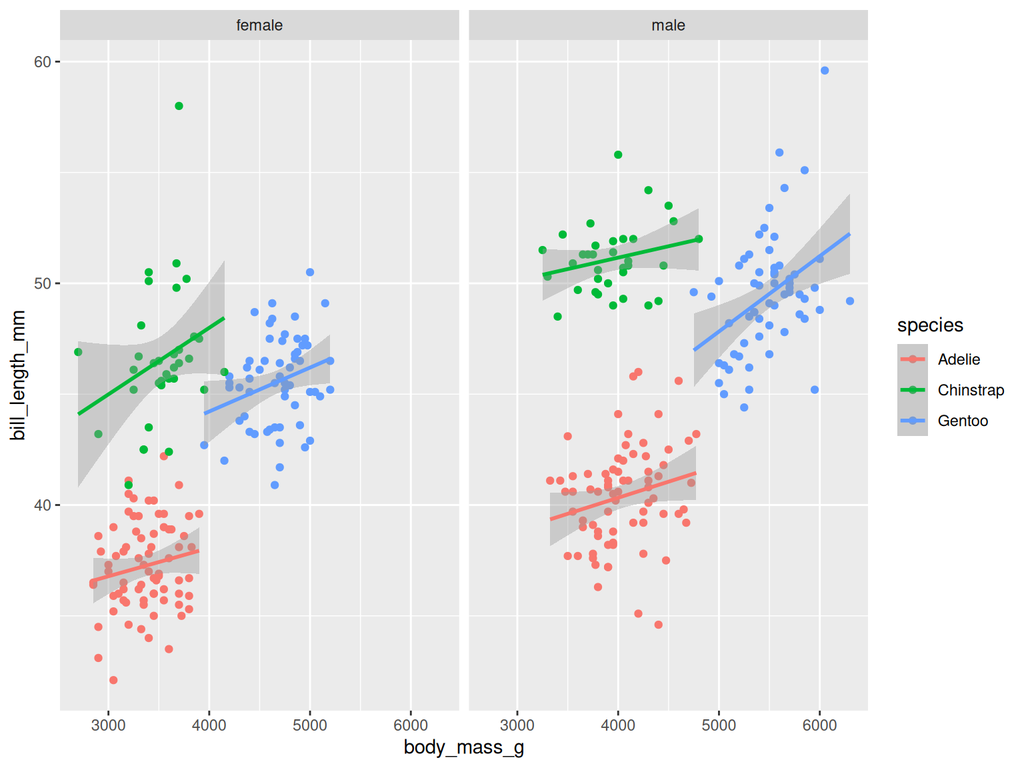

```r
penguins |>
  dplyr::filter(!is.na(sex)) |>
  ggplot(
    aes(
      body_mass_g, bill_length_mm, colour = species
    )
  ) +
  geom_point() +
  geom_smooth(method = "lm") +
  facet_wrap(~sex)
```

It appears plausible that slopes may differ between sex and that different intercepts may also be required. A key question might be “*Are the differences in slope & intercept due to sex consistent between species?*”

We could fit interaction terms between sex & both existing terms, then allow `step()` to determine if:

1. any interaction term improves the model
2. if the inclusion of sex alone improves the fit

If a term is retained y `step()`, we can assume it improves the model

```r
penguin_sex_lm <- lm(bill_length_mm ~ species*sex + body_mass_g*sex, data = penguins) |>
  step()
```

```
Start:  AIC=546.01
bill_length_mm ~ species * sex + body_mass_g * sex

                  Df Sum of Sq    RSS    AIC
- sex:body_mass_g  1     0.021 1635.6 544.02
<none>                         1635.6 546.01
- species:sex      2    40.761 1676.4 550.21

Step:  AIC=544.02
bill_length_mm ~ species + sex + body_mass_g + species:sex

              Df Sum of Sq    RSS    AIC
<none>                     1635.6 544.02
- species:sex  2    40.747 1676.4 548.21
- body_mass_g  1   117.712 1753.3 565.16
```

```r
summary(penguin_sex_lm) |> pander(add.significance.stars = TRUE)
```

|  | Estimate | Std. Error | t value | Pr(>\|t\|) |  |
| --- | --- | --- | --- | --- | --- |
| **(Intercept)** | 30.72 | 1.374 | 22.36 | 8.601e-68 | * * * |
| **speciesChinstrap** | 9.009 | 0.4694 | 19.19 | 1.801e-55 | * * * |
| **speciesGentoo** | 5.764 | 0.6563 | 8.783 | 9.172e-17 | * * * |
| **sexmale** | 1.825 | 0.4587 | 3.978 | 8.579e-05 | * * * |
| **body_mass_g** | 0.001939 | 0.0004004 | 4.844 | 1.973e-06 | * * * |
| **speciesChinstrap:sexmale** | 1.898 | 0.6661 | 2.849 | 0.004668 | * * |
| **speciesGentoo:sexmale** | 0.5242 | 0.5558 | 0.943 | 0.3464 |  |

Fitting linear model: bill_length_mm ~ species + sex + body_mass_g + species:sex

| Observations | Residual Std. Error | $R^2$ | Adjusted $R^2$ |
| --- | --- | --- | --- |
| 333 | 2.24 | 0.8353 | 0.8322 |

The interaction term between `body_mass_g` and `sex` was removed, indicating that there are no differences in the slope due to `sex`. However, the retention of the interaction term between `species` and `sex` suggests the both sex and species-based intercepts are an improvement to the model.

We could also check this using ANOVA

```r
anova(bill_length_sp_lm, penguin_sex_lm) |>
  pander(missing = "")
```

Analysis of Variance Table

| Res.Df | RSS | Df | Sum of Sq | F | Pr(>F) |
| --- | --- | --- | --- | --- | --- |
| 329 | 1926 |  |  |  |  |
| 326 | 1636 | 3 | 290.1 | 19.27 | 1.574e-11 |

Including `sex` as an interaction with `species` appears to significantly improve the model.

Making sure that this has not introduced any violations of the linear regression assumptions

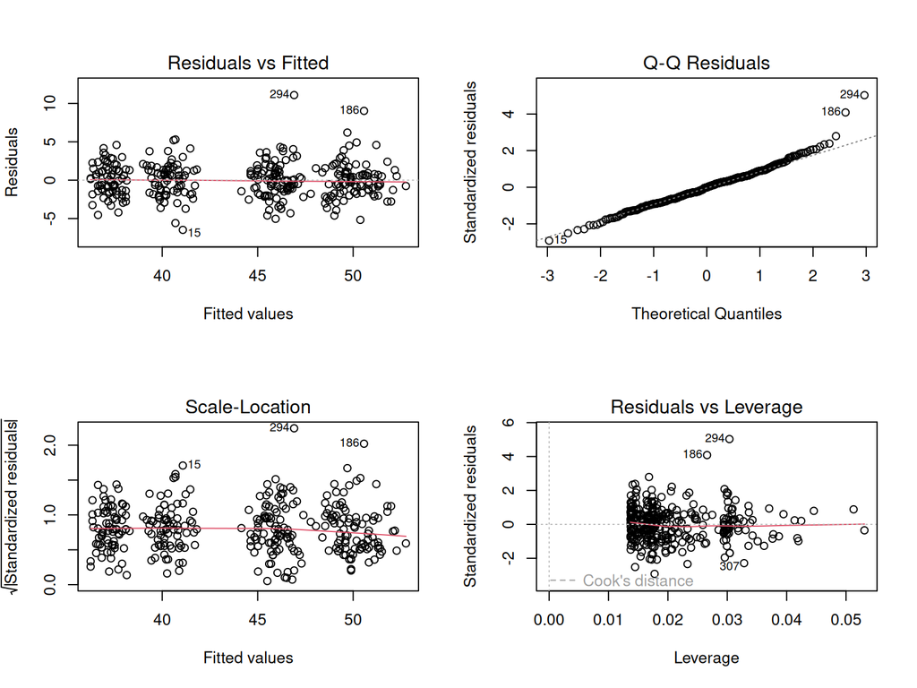

```r
par(mfrow = c(2, 2))
plot(penguin_sex_lm)
```

```r
par(mfrow = c(1, 1))
```

### Challenges 2-3

```r
pigs <- read_csv("data/pigs.csv") |>
  mutate(
    supp = fct(supp),
    dose = fct(dose, levels = c("Low", "Med", "High"))
  )
```

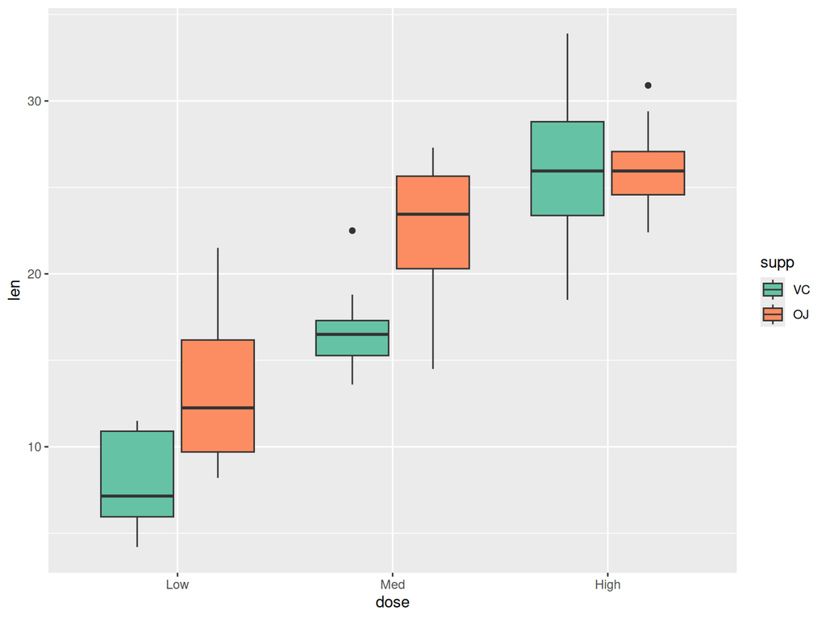

```r
pigs |>
  ggplot(aes(dose, len, fill = supp)) +
  geom_boxplot() +
  scale_fill_brewer(palette = "Set2")
```

### Challenge 4

```r
pigs_lm <- lm(len ~ (supp + dose)^2, data = pigs) |>
  step()
```

```
Start:  AIC=160.43
len ~ (supp + dose)^2

            Df Sum of Sq    RSS    AIC
<none>                   712.11 160.43
- supp:dose  2    108.32 820.43 164.93
```

The initial model appears to be a good one, with removal of terms failing to improve the model.

### Challenge 5

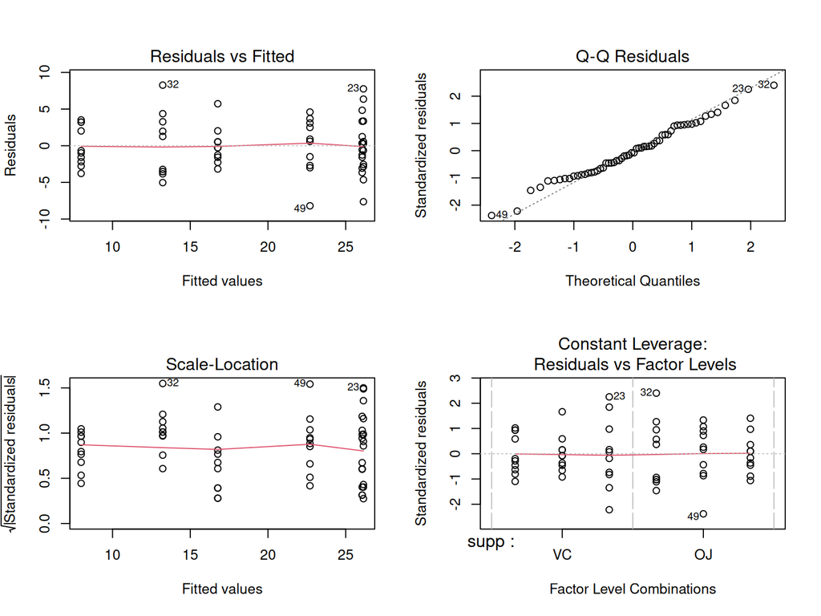

```r
par(mfrow = c(2, 2))
plot(pigs_lm)
```

```r
par(mfrow = c(1, 1))
```

All diagnostic plots seem to support residuals which follow $\epsilon_i \sim \mathcal{N}(0, \sigma)$

### Challenge 6

```r
pander(pigs_lm, add.significance.stars = TRUE)
```

Fitting linear model: len ~ (supp + dose)^2

|  | Estimate | Std. Error | t value | Pr(>\|t\|) |  |
| --- | --- | --- | --- | --- | --- |
| **(Intercept)** | 7.98 | 1.148 | 6.949 | 4.984e-09 | * * * |
| **suppOJ** | 5.25 | 1.624 | 3.233 | 0.002092 | * * |
| **doseMed** | 8.79 | 1.624 | 5.413 | 1.463e-06 | * * * |
| **doseHigh** | 18.16 | 1.624 | 11.18 | 1.131e-15 | * * * |
| **suppOJ:doseMed** | 0.68 | 2.297 | 0.2961 | 0.7683 |  |
| **suppOJ:doseHigh** | -5.33 | 2.297 | -2.321 | 0.02411 | * |

- $\beta_0$: The Intercept represents the expected odontoblast length for VC at low dose
- $\beta_1$: **suppOJ** represents the different in expected odontoblast length between OJ and VC with both at low dose
- $\beta_2$: **doseMed** represents the different in expected odontoblast length between Med and Low dose for VC
- $\beta_3$: **doseHigh** represents the different in expected odontoblast length between High and Low dose for VC
- $\beta_4$: **suppOJ:doseMed** represents the difference in the expected odontoblast length at medium dose for OJ than the estimate obtained simply by summing the estimates $\beta_0 + \beta_1 + \beta_2$
- $\beta_5$: **suppOJ:doseHigh** represents the difference in the expected odontoblast length at high dose for OJ than the estimate obtained simply by summing the estimates $\beta_0 + \beta_1 + \beta_3$

### Challenge 7

```r
new_pigs <- tibble(dose = "High", supp = "VC")
pred_pigs <- predict(
  pigs_lm, newdata = new_pigs, interval = "confidence", level = 0.99
)
pred_pigs
```

```
    fit      lwr      upr
1 26.14 23.07391 29.20609
```

- The expected odontoblast length for a guinea pig given high-dose vitamin C is the fitted value (26.14)
- The true average length for a guinea pig given high-dose vitamin C is 99% likely to be between the values named `lwr` and `upr`, i.e. [23.07, 29.21]